# Automotive Fuel Efficiency Analysis

## Automotive Data Analysis Project: Evaluating Fuel Efficiency and Its Relationship to Engine and Design Characteristics Across Geographic Regions.

[figure not shown]

```python
import pandas as pd
import numpy as np
import matplotlib.pyplot as plt
import seaborn as sns
```

```python
df = pd.read_csv('cars.csv')

print(df.head())
```

```
                         Car   MPG  Cylinders  Displacement  Horsepower  \
0  Chevrolet Chevelle Malibu  18.0          8         307.0         130
1          Buick Skylark 320  15.0          8         350.0         165
2         Plymouth Satellite  18.0          8         318.0         150
3              AMC Rebel SST  16.0          8         304.0         150
4                Ford Torino  17.0          8         302.0         140

   Weight  Acceleration  Model Origin Origin Model
0    3504          12.0     70     US        US 70
1    3693          11.5     70     US        US 70
2    3436          11.0     70     US        US 70
3    3433          12.0     70     US        US 70
4    3449          10.5     70     US        US 70
```

```python
print(df.info())

print(df.isnull().sum())

df_cleaned = df.dropna(subset=['MPG', 'Horsepower', 'Weight'])

numeric_cols = ['MPG', 'Cylinders', 'Displacement', 'Horsepower', 'Weight', 'Acceleration']
df_cleaned[numeric_cols] = df_cleaned[numeric_cols].apply(pd.to_numeric, errors='coerce')

df_cleaned = df_cleaned.dropna(subset=numeric_cols)
```

```
<class 'pandas.core.frame.DataFrame'>
RangeIndex: 406 entries, 0 to 405
Data columns (total 10 columns):
 #   Column        Non-Null Count  Dtype
---  ------        --------------  -----
 0   Car           406 non-null    object
 1   MPG           406 non-null    float64
 2   Cylinders     406 non-null    int64
 3   Displacement  406 non-null    float64
 4   Horsepower    406 non-null    int64
 5   Weight        406 non-null    int64
 6   Acceleration  406 non-null    float64
 7   Model         406 non-null    int64
 8   Origin        406 non-null    object
 9   Origin Model  406 non-null    object
dtypes: float64(3), int64(4), object(3)
memory usage: 31.8+ KB
None
Car             0
MPG             0
Cylinders       0
Displacement    0
Horsepower      0
Weight          0
Acceleration    0
Model           0
Origin          0
Origin Model    0
dtype: int64
```

```python
def detect_outliers(column):
    Q1 = column.quantile(0.25)
    Q3 = column.quantile(0.75)
    IQR = Q3 - Q1
    lower_bound = Q1 - 1.5 * IQR
    upper_bound = Q3 + 1.5 * IQR
    return (column < lower_bound) | (column > upper_bound)

outliers_mpg = detect_outliers(df_cleaned['MPG'])
outliers_hp = detect_outliers(df_cleaned['Horsepower'])
outliers_weight = detect_outliers(df_cleaned['Weight'])

print(f"outliers in MPG: {outliers_mpg.sum()}")
print(f"outliers in Horsepower: {outliers_hp.sum()}")
print(f"outliers in Weight: {outliers_weight.sum()}")

print("\noutliers in MPG:")
print(df_cleaned[outliers_mpg]['MPG'])

df_no_outliers = df_cleaned[~(outliers_mpg | outliers_hp | outliers_weight)].copy()
```

```
outliers in MPG: 0
outliers in Horsepower: 8
outliers in Weight: 0

outliers in MPG:
Series([], Name: MPG, dtype: float64)
```

```python
print("\ndescribtive data analysis:")
print(df_no_outliers.describe())

print("\nditribution based on Cylinders :")
print(df_no_outliers['Cylinders'].value_counts())

print("\nditribution based on Origin:")
print(df_no_outliers['Origin'].value_counts())
```

```
describtive data analysis:
              MPG   Cylinders  Displacement  Horsepower       Weight  \
count  398.000000  398.000000    398.000000  398.000000   398.000000
mean    23.245729    5.424623    190.003769  101.163317  2951.974874
std      8.368546    1.691018    100.244490   37.276568   829.489397
min      0.000000    3.000000     68.000000    0.000000  1613.000000
25%     17.500000    4.000000    101.750000   75.000000  2220.750000
50%     23.000000    4.000000    145.500000   92.000000  2797.500000
75%     29.000000    7.500000    260.000000  120.000000  3568.250000
max     46.600000    8.000000    429.000000  210.000000  5140.000000

       Acceleration       Model
count    398.000000  398.000000
mean      15.623116   76.017588
std        2.724295    3.717640
min        8.000000   70.000000
25%       13.925000   73.000000
50%       15.500000   76.000000
75%       17.275000   79.000000
max       24.800000   82.000000

ditribution based on Cylinders :
Cylinders
4    207
8    100
6     84
3      4
5      3
Name: count, dtype: int64

ditribution based on Origin:
Origin
US        246
Japan      79
Europe     73
Name: count, dtype: int64
```

### What is the most common fuel efficiency range for vehicles in this dataset, and how are extreme values distributed?

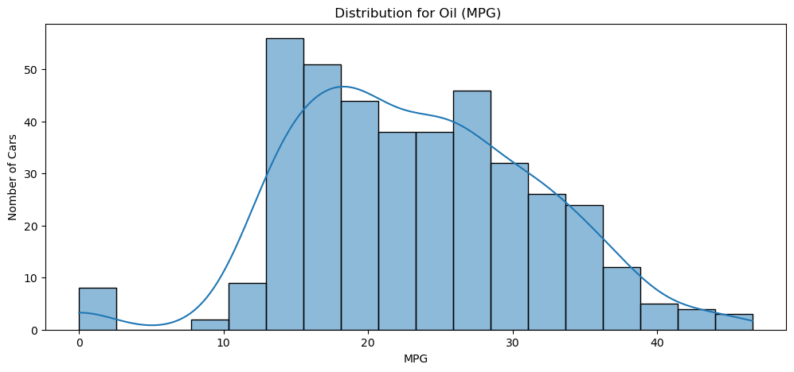

```python
plt.figure(figsize=(12, 5))

sns.histplot(df_no_outliers['MPG'], bins=18, kde=True)
plt.title(' Distribution for Oil (MPG)')
plt.xlabel('MPG')
plt.ylabel('Nomber of Cars')
plt.show()
```

## Insights:

### Minimal low-MPG vehicles (<10) suggest very inefficient cars were uncommon in this dataset.

## How has average vehicle fuel efficiency changed from 1970 to 1982, and what trends are visible?

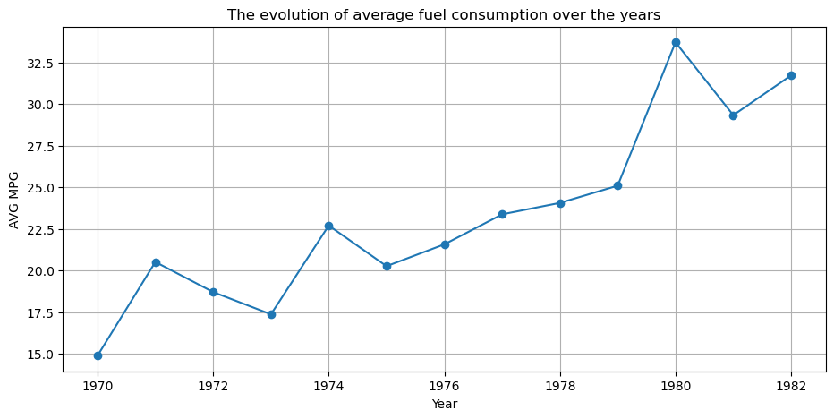

```python
df_no_outliers['Full_Year'] = 1900 + df_no_outliers['Model']

mpg_by_year = df_no_outliers.groupby('Full_Year')['MPG'].mean()

plt.figure(figsize=(11, 5))
mpg_by_year.plot(kind='line', marker='o')
plt.title('The evolution of average fuel consumption over the years')
plt.xlabel('Year')
plt.ylabel('AVG MPG')
plt.grid(True)
plt.show()
```

## How does engine power (horsepower) affect fuel efficiency across different vehicle origins, and which region produces the most efficient high-power vehicles?

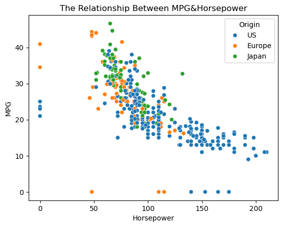

```python
sns.scatterplot(data=df_no_outliers, x='Horsepower', y='MPG', hue='Origin')
plt.title('The Relationship Between MPG&Horsepower')
plt.show()
```

## Insights:

### Key Takeaway: While power and efficiency are generally trade-offs, Japanese automakers appear most successful at balancing these factors during this period.

## How does the number of cylinders impact a vehicle's fuel efficiency, and what's the optimal cylinder count for MPG?

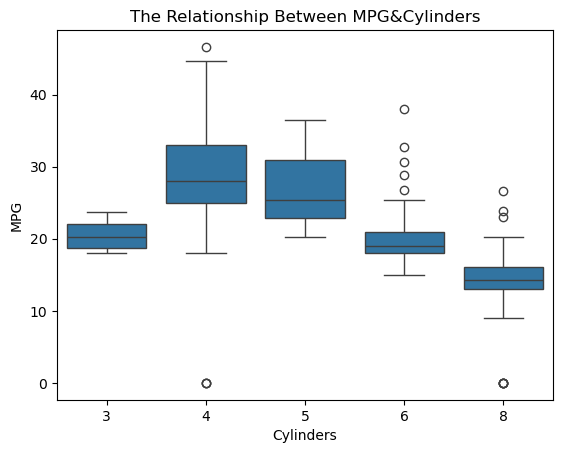

```python
sns.boxplot(data=df_no_outliers, x='Cylinders', y='MPG')
plt.title('The Relationship Between MPG&Cylinders')
plt.show()
```

## Insights:

### Notable exceptions:

### Some 6-cylinder outliers match 4-cylinder efficiency

### Minimal 3-cylinder data points suggest emerging small-engine technology

### Practical Implication: Consumers prioritizing fuel economy should favor 4-cylinder vehicles, while those needing power must accept lower MPG.

## Which region produces the most fuel-efficient vehicles on average, and how significant are the differences?

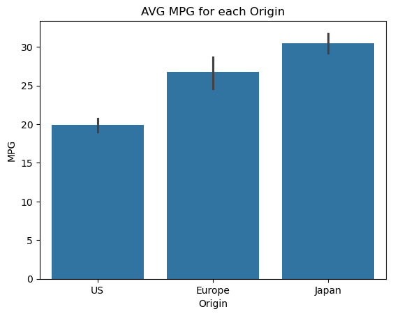

```python
sns.barplot(data=df_no_outliers, x='Origin', y='MPG', estimator=np.mean)
plt.title('AVG MPG for each Origin')
plt.show()
```

## Insights:

### US lagging: American vehicles have lowest average MPG (~15-20), consistent with larger engine preferences.

### Key Takeaway: National automotive priorities clearly impact efficiency, with Japanese makers delivering 25-50% better fuel economy than US counterparts during this period.

## Which vehicle features have the strongest relationships with fuel efficiency (MPG), and how do key parameters interrelate?

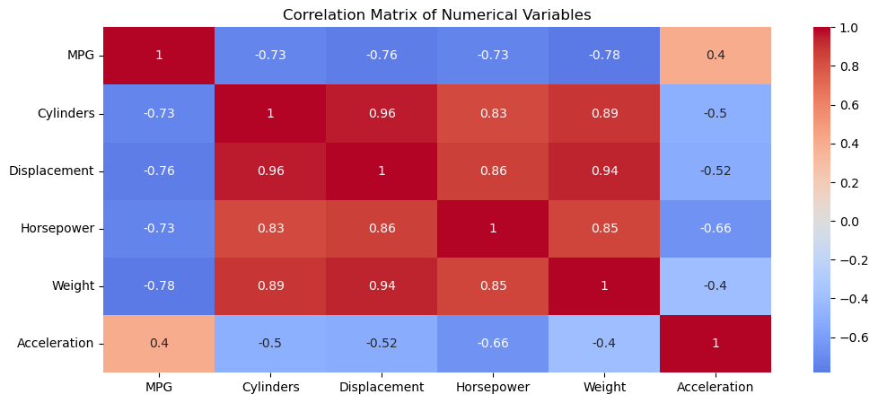

```python
# Correlation Matrix
corr_matrix = df_no_outliers[numeric_cols].corr()

plt.figure(figsize=(12, 5))
sns.heatmap(corr_matrix, annot=True, cmap='coolwarm', center=0)
plt.title('Correlation Matrix of Numerical Variables')
plt.show()
```

## Insights:

### Weight ↔ Horsepower (0.85)

### Acceleration has weak relationships:

### Slight positive with MPG (0.4)

### Mild inverse with cylinders (-0.5)

## Key Takeaway: Fuel efficiency is primarily determined by engine size (cylinders/displacement) and vehicle weight, not acceleration performance.